# Act Report

In this project, the dataset to analyze and visualize is the tweet archive of Twitter user @dog_rates, also known as WeRateDogs. This Twitter account rates people’s dogs with a humorous comment about the dog. It was started in 2015.

The data contains basic tweet data for all 5000+ of their tweets. A provided “enhanced” version filtered for tweets with ratings only (2356 records). However, this version needed further assessment and cleaning to be able to use it for analysis and visualization.

After the data wrangling process, the Twitter Archive master file ended up containing 1968 records. Not all of the detected (tidiness and quality) issues were addressed per the scope of this project since it would require a lot of time; but this final version provided with a file suitable for performing EDA.

Therefore, per the following tables and charts:

```python
df.describe()
```

|  | tweet_id | rating_numerator | rating_denominator | favorites | retweets | user_followers | user_favourites |
| --- | --- | --- | --- | --- | --- | --- | --- |
| count | 1.969000e+03 | 1968.000000 | 1968.0 | 1968.000000 | 1968.000000 | 1.968000e+03 | 1968.000000 |
| mean | 7.360685e+17 | 11.441057 | 10.0 | 8807.427846 | 2679.191565 | 7.495736e+06 | 140351.012195 |
| std | 6.754581e+16 | 39.855466 | 0.0 | 12896.284239 | 4768.008921 | 6.389432e+01 | 0.130906 |
| min | 6.660209e+17 | 0.000000 | 10.0 | 80.000000 | 12.000000 | 7.495703e+06 | 140351.000000 |
| 25% | 6.758782e+17 | 10.000000 | 10.0 | 1902.750000 | 595.000000 | 7.495706e+06 | 140351.000000 |
| 50% | 7.088343e+17 | 11.000000 | 10.0 | 3979.500000 | 1290.000000 | 7.495727e+06 | 140351.000000 |
| 75% | 7.881506e+17 | 12.000000 | 10.0 | 10980.500000 | 3065.000000 | 7.495765e+06 | 140351.000000 |
| max | 8.924206e+17 | 1776.000000 | 10.0 | 164719.000000 | 83933.000000 | 7.496379e+06 | 140353.000000 |

```python
# Tweet with maximum rating numerator
df[df.rating_numerator==1776]
```

|  | tweet_id | timestamp | source | text | expanded_urls | rating_numerator | rating_denominator | name | jpg_url | stage | favorites | retweets | user_followers | user_favourites | language |
| --- | --- | --- | --- | --- | --- | --- | --- | --- | --- | --- | --- | --- | --- | --- | --- |
| 722 | 749981277374128128 | 2016-07-04 15:00:45 | <a href="https://about.twitter.com/products/tweetdeck" rel="nofollow">TweetDeck</a> | This is Atticus. He's quite simply America af. 1776/10 https://t.co/GRXwMxLBkh | https://twitter.com/dog_rates/status/749981277374128128/photo/1 | 1776.0 | 10.0 | Atticus | https://pbs.twimg.com/media/CmgBZ7kWcAAlzFD.jpg | NaN | 5403.0 | 2644.0 | 7495726.0 | 140351.0 | en |

```python
# Tweet with maximum favorites
df[df.favorites==164719]
```

|  | tweet_id | timestamp | source | text | expanded_urls | rating_numerator | rating_denominator | name | jpg_url | stage | favorites | retweets | user_followers | user_favourites | language |
| --- | --- | --- | --- | --- | --- | --- | --- | --- | --- | --- | --- | --- | --- | --- | --- |
| 768 | 744234799360020481 | 2016-06-18 18:26:18 | <a href="http://twitter.com/download/iphone" rel="nofollow">Twitter for iPhone</a> | Here's a doggo realizing you can stand in a pool. 13/10 enlightened af (vid by Tina Conrad) https://t.co/7wE9LTEXC4 | https://twitter.com/dog_rates/status/744234799360020481/video/1 | 13.0 | 10.0 | NaN | https://pbs.twimg.com/ext_tw_video_thumb/744234667679821824/pu/img/1GaWmtJtdqzZV7jy.jpg | doggo | 164719.0 | 83933.0 | 7495726.0 | 140351.0 | en |

```python
# Tweet with maximum retweets
df[df.retweets==83933]
```

|  | tweet_id | timestamp | source | text | expanded_urls | rating_numerator | rating_denominator | name | jpg_url | stage | favorites | retweets | user_followers | user_favourites | language |
| --- | --- | --- | --- | --- | --- | --- | --- | --- | --- | --- | --- | --- | --- | --- | --- |
| 768 | 744234799360020481 | 2016-06-18 18:26:18 | <a href="http://twitter.com/download/iphone" rel="nofollow">Twitter for iPhone</a> | Here's a doggo realizing you can stand in a pool. 13/10 enlightened af (vid by Tina Conrad) https://t.co/7wE9LTEXC4 | https://twitter.com/dog_rates/status/744234799360020481/video/1 | 13.0 | 10.0 | NaN | https://pbs.twimg.com/ext_tw_video_thumb/744234667679821824/pu/img/1GaWmtJtdqzZV7jy.jpg | doggo | 164719.0 | 83933.0 | 7495726.0 | 140351.0 | en |

- The doggo with maximum favorites and retweets is the corresponding to tweet_id 744234799360020481.
- However it does not have the maximum rating.
- Atticus (tweet_id 749981277374128128) on the contrary is the maximum rated dog, but has a number of favorites much less than the mean, and has a number of retweets very close to the average. This rating seems to be an outlier.

For further analysis, it is suggested to see the correlation between these three variables: ratings, favorites and retweets.

##### Amount of Tweets overtime

```python
df['timestamp'].apply(lambda x: x.strftime('%Y-%m')).value_counts().sort_index()
```

```
2015-11    294
2015-12    360
2016-01    166
2016-02    108
2016-03    118
2016-04     54
2016-05     56
2016-06     79
2016-07     87
2016-08     59
2016-09     63
2016-10     65
2016-11     52
2016-12     54
2017-01     66
2017-02     64
2017-03     47
2017-04     40
2017-05     42
2017-06     44
2017-07     49
2017-08      2
Name: timestamp, dtype: int64
```

Per the number of monthly tweets, the tweeting from this account shows a descending trend overtime. The dataset includes tweets posted no later than August 1st, 2017.

##### Popular Dog Names

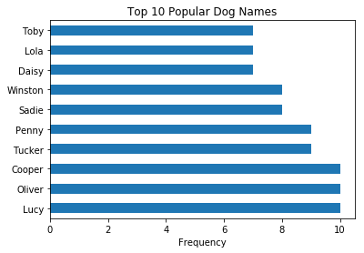

```python
top_names = df.name.value_counts()[1:11]

ax = top_names.plot('barh', title='Top 10 Popular Dog Names')
ax.set_xlabel("Frequency");
```

The above visualization shows the top popular names for dogs, being the top three Lucy, Oliver and Cooper

##### Dog Rating Distribution

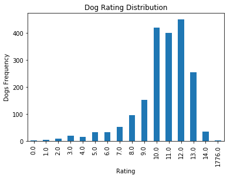

```python
ax = df.rating_numerator.value_counts().sort_index().plot('bar', title = 'Dog Rating Distribution')
ax.set_xlabel("Rating")
ax.set_ylabel("Dogs Frequency");
```

Although the ratings have a denominator of 10, some numerators are greater than this denominator. Around 450 are rated 12, more than 400 are rated 10, and 400 are rated 11. The dog rating (numerator) averages 11.44.

Why? Because "they're good dogs Brent."

##### Dog Stage Proportion

```python
rates_images_df.stage.value_counts()
```

```
pupper     202
doggo       64
puppo       23
floofer      8
Name: stage, dtype: int64
```

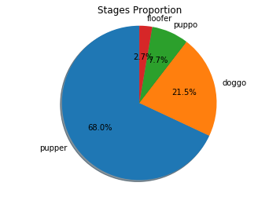

```python
stages = df.stage.value_counts()

fig1, ax1 = plt.subplots()
ax1.pie(stages, labels=stages.index, autopct='%1.1f%%', shadow=True, startangle=90)
ax1.axis('equal')  # Equal aspect ratio ensures that pie is drawn as a circle.

ax1.set_title("Stages Proportion")

plt.show()
```

Out of 297 dogs (which are the categorized ones), 68% are classified as puppers, 21.5% as doggo, 7.7% as puppo and 2.7% as floofer. These proportions might be the trend, however, the uncategorized dogs need to be filled out with their corresponding stage to show or not if these numbers are kept.

Althought the data wrangling is time consuming, it is neccesary to invest time on assessing and cleaning the most it can be, in order to be able to analyze and visualize a more accurate data and get real results. The analysis without cleaning or over a still dirty-messy data might give, pretty much, wrong insights and therefore a wrong perception of the data. Also, it might take more time time and complexity to handle it.

The current analysis and visualizations are based on an assessed and clean data, but we need to keep in mind there is still more room for further wrangling work.